# AS3

Richard Yang

2023-07-08

```r
library(fpp)
library(TSA)
```

```r
library(ggplot2)
library(forecast)
```

## Question 1:

Load the usgdp.rda dataset and split it into a training dataset (1960 - 2012) and a test dataset (2013 - 2017)

```r
load(file = 'C:/Users/Richa/Desktop/TS/week3/usgdp.rda')
usgdp = ts(usgdp['GDP'], start = 1960, end =2017, frequency = 1)
train = window(usgdp, 1960, 2012)
test = window(usgdp, 2013, 2017)
```

(5 points) Question 2: Plot the training dataset. Is the Box-Cox transformation necessary for this data? Why?

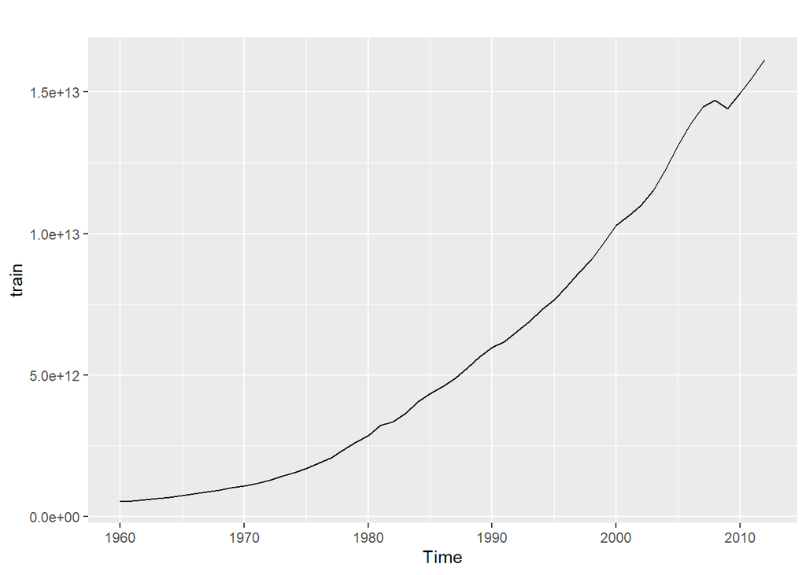

```r
autoplot(train)
```

As we can see from the plot above, the box-cox transformation is necessary for this data. The plot is concave up, and the variance is not constant and increasing over time.

```r
# Apply function to find lambda value
lamda = BoxCox.lambda(train)
lamda
```

```
## [1] 0.2310656
```

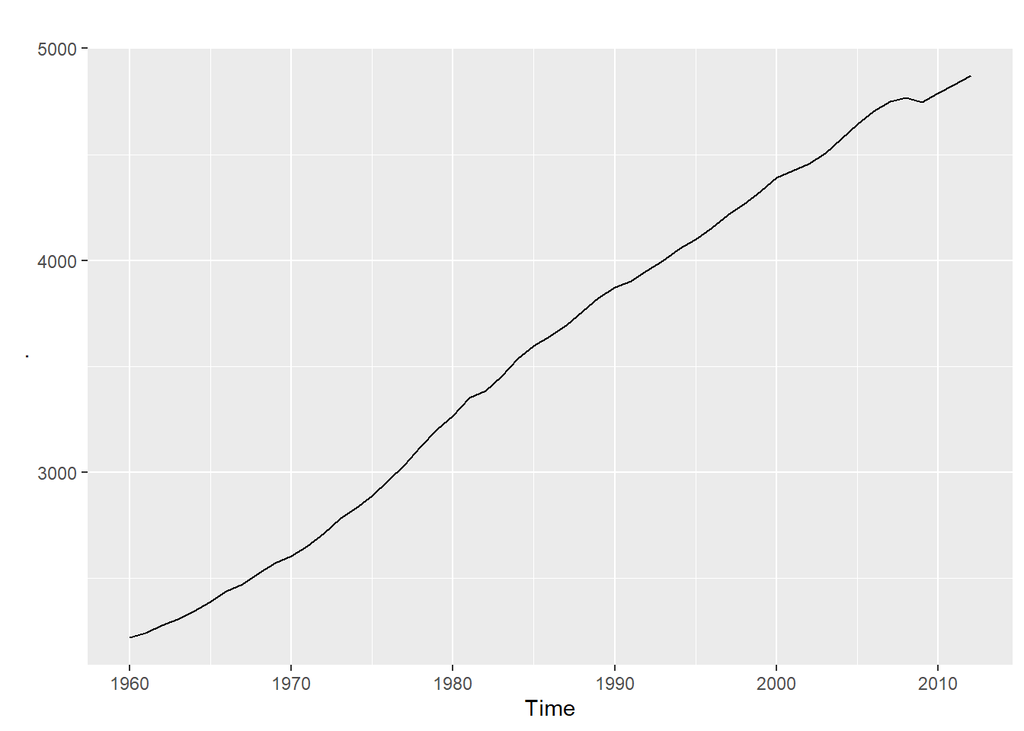

```r
trainBC = train %>% BoxCox(lambda = lamda)
trainBC%>% autoplot()
```

It is clear that after this adjustment, the variations tend to be more constant

## Question 3:

Plot the 1st and 2nd order difference of the data. Apply KPSS Test for Stationarity to determine which difference order results in a stationary dataset.

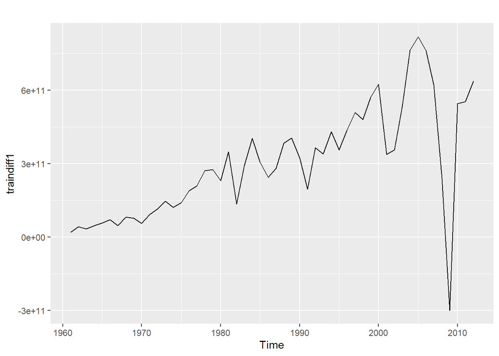

```r
traindiff1 = diff(train, differences = 1)
autoplot(traindiff1)
```

```r
kpss.test(traindiff1)
```

```
##
##  KPSS Test for Level Stationarity
##
## data:  traindiff1
## KPSS Level = 1.1194, Truncation lag parameter = 3, p-value = 0.01
```

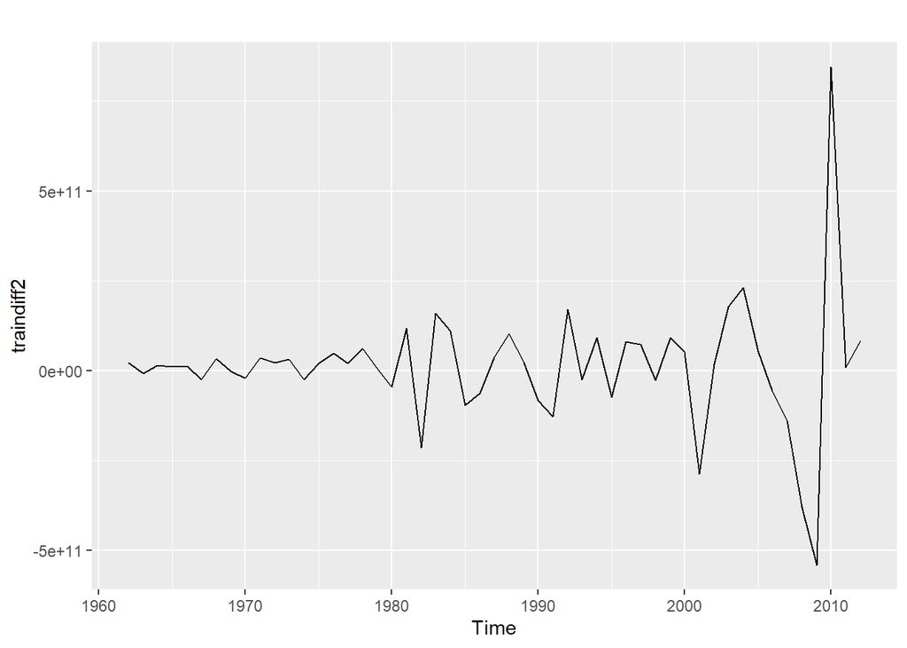

```r
traindiff2 = diff(train, differences = 2)
autoplot(traindiff2)
```

```r
kpss.test(traindiff2)
```

```
##
##  KPSS Test for Level Stationarity
##
## data:  traindiff2
## KPSS Level = 0.030686, Truncation lag parameter = 3, p-value = 0.1
```

Since for the KPSS test, If the p-value is below a certain significance level (e.g., 0.05), you may reject the null hypothesis and conclude that the time series is non-stationary.

For 1st order differencing, we can see that the p-value = **0.01** < 0.05. Therefore, we reject the null hypothesis and conclude that the first differenced data is non-stationary.

For 2nd order differencing, we can see that the p-value = **0.1** > 0.05. Therefore, we cannot reject the null hypothesis and conclude that the second differenced data might be stationary.

## Question 4:

Fit a suitable ARIMA model to the training dataset using the auto.arima() function. Remember to transform the data first, if necessary, by setting the 𝑙𝑎𝑚𝑏𝑑𝑎 argument. Report the resulting 𝑝, 𝑑, 𝑞 and the coefficients values.

```r
# I already transformed the data in Question 2, and the transformaed data is named as 'train_BC'
AR_fit = auto.arima(trainBC)
summary(AR_fit)
```

```
## Series: trainBC
## ARIMA(1,1,0) with drift
##
## Coefficients:
##          ar1    drift
##       0.4728  50.3366
## s.e.  0.1242   4.3713
##
## sigma^2 = 295.7:  log likelihood = -220.81
## AIC=447.62   AICc=448.12   BIC=453.47
##
## Training set error measures:
##                    ME     RMSE      MAE        MPE      MAPE      MASE
## Training set 0.394498 16.70324 12.59926 0.01142931 0.3639134 0.2430255
##                     ACF1
## Training set -0.03210499
```

As we can see from the summary table, the suitable Arima model generated by auto arima function is ARIMA(1,1,0).P=1,d=1,q=0. The Coefficient for ar1 is 0.4728, and for drift is 50.3366

## Question 5:

Compute the sample Extended ACF (EACF) and use the Arima() function to try some other plausible models by experimenting with the orders chosen. Limit your models to 𝑞, 𝑝 ≤ 2 and 𝑑 ≤ 2. Use the model summary() function to compare the Corrected Akaike information criterion (i.e., AICc) values (Note: Smaller values indicated better models).

```r
eacf(trainBC)
```

```
## AR/MA
##   0 1 2 3 4 5 6 7 8 9 10 11 12 13
## 0 x x x x x x x x x x x  x  o  o
## 1 x o o o o x o o o o o  o  o  o
## 2 o o o o o o o o o o o  o  o  o
## 3 x o o o o o o o o o o  o  o  o
## 4 x o o o o o o o o o o  o  o  o
## 5 x o o o o o o o o o o  o  o  o
## 6 x o o x o o o o o o o  o  o  o
## 7 x x o o o o o o o o o  o  o  o
```

```r
library(forecast)

# Create an empty matrix to store the AICc values
aicc_matrix <- matrix(NA, nrow = 3, ncol = 3)

# Initialize variables for the lowest AICc value and its corresponding order
lowest_aicc <- Inf
best_order <- c(0, 0, 0)

# Iterate through all combinations of p, d, and q
for (p in 1:2) {
  for (d in 0:2) {
    for (q in 0:2) {
      # Fit the ARIMA model
      fit <- Arima(trainBC, order = c(p, d, q))

      # Calculate the AICc value and store it in the matrix
      aicc_matrix[p, d + 1] <- summary(fit)$aicc

      # Print the AICc value for the current model
      cat("AICc (p =", p, "d =", d, "q =", q, "):", summary(fit)$aicc, "\n")

      # Check if the current AICc value is lower than the lowest AICc value found so far
      if (summary(fit)$aicc < lowest_aicc) {
        lowest_aicc <- summary(fit)$aicc
        best_order <- c(p, d, q)
      }
    }
  }
}
```

```
## AICc (p = 1 d = 0 q = 0 ): 586.9129
## AICc (p = 1 d = 0 q = 1 ): 551.1682
## AICc (p = 1 d = 0 q = 2 ): 689.26
## AICc (p = 1 d = 1 q = 0 ): 460.991
## AICc (p = 1 d = 1 q = 1 ): 455.0258
## AICc (p = 1 d = 1 q = 2 ): 454.6279
## AICc (p = 1 d = 2 q = 0 ): 448.4341
## AICc (p = 1 d = 2 q = 1 ): 442.5009
## AICc (p = 1 d = 2 q = 2 ): 444.6169
## AICc (p = 2 d = 0 q = 0 ): 482.4182
## AICc (p = 2 d = 0 q = 1 ): 649.6028
## AICc (p = 2 d = 0 q = 2 ): 477.4339
## AICc (p = 2 d = 1 q = 0 ): 459.9134
## AICc (p = 2 d = 1 q = 1 ): 454.9093
## AICc (p = 2 d = 1 q = 2 ): 457.087
## AICc (p = 2 d = 2 q = 0 ): 447.6488
## AICc (p = 2 d = 2 q = 1 ): 444.4861
## AICc (p = 2 d = 2 q = 2 ): 443.1007
```

```r
# Print the model with the lowest AICc value
cat("\nBest model - AICc:", lowest_aicc, "\n")
```

```
##
## Best model - AICc: 442.5009
```

```r
cat("Best order:", paste("p =", best_order[1], "d =", best_order[2], "q =", best_order[3]), "\n")
```

```
## Best order: p = 1 d = 2 q = 1
```

As we can see from the result above, the best model is model has p = 1 d = 2 q = 1 with an AIC = 442.5

## Question 6:

Use the model chosen in Question 4 to forecast and plot the GDP forecasts with 80 and 95 % confidence levels for 2013 - 2017 (Test Period).

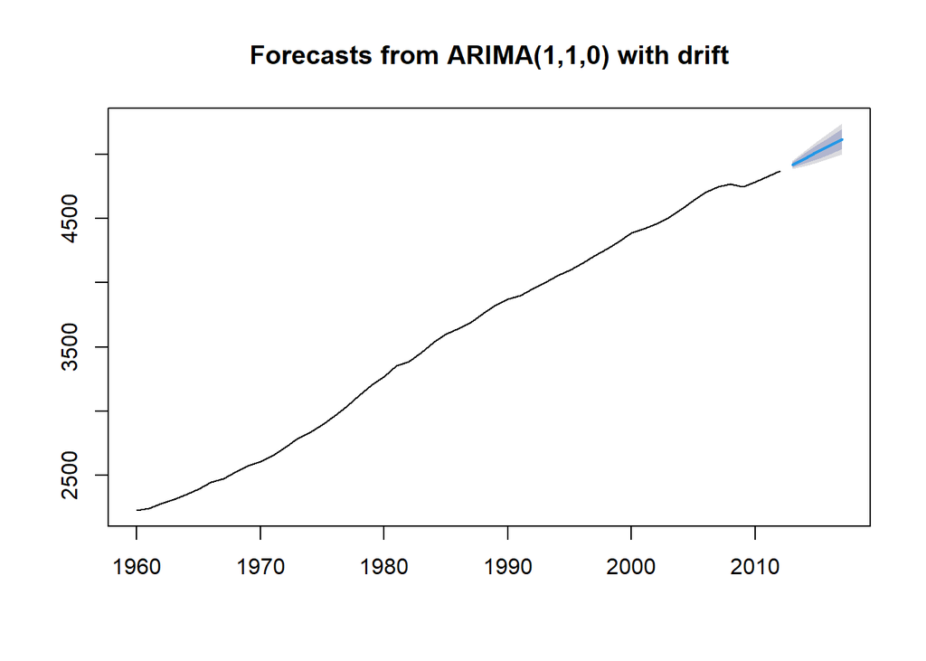

```r
predicted = forecast(AR_fit, h = 5, level = c(80,95))
plot(predicted)
```

We can further investigate the detailed information hidden in the above plot for the forcasting period

[figure not shown]

```r
# Generate forecasts using an AR model
predicted <- forecast(AR_fit, h = 5, level = c(80, 95))

# Create a time sequence for x-axis
time_sequence <- seq(length(predicted$mean))

# Plotting the forecasts
plot(time_sequence, predicted$mean, type = "l", ylim = range(predicted$lower, predicted$upper),
     xlab = "Time", ylab = "Forecast", main = "AR Model Forecasts")
polygon(c(time_sequence, rev(time_sequence)), c(predicted$upper[, 2], rev(predicted$lower[, 2])),
        col = "gray", border = NA)
polygon(c(time_sequence, rev(time_sequence)), c(predicted$upper[, 1], rev(predicted$lower[, 1])),
        col = "lightblue", border = NA)
lines(time_sequence, predicted$mean, col = "red", lwd = 2)

# Adding legend
legend("topleft", legend = c("Point Forecast", "80% CI", "95% CI"),
       col = c("red", "gray", "lightblue"), lty = 1, lwd = 2, fill = c("red", "gray", "lightblue"),
       bty = "n")
```

[output not shown]

## Question 7:

Compare your forecasts with the actual values using error = actual - estimate and plot the errors. (Note: Use the forecast $mean element for the forecast estimate)

```r
estimate <- InvBoxCox((predicted$mean), lambda = lamda)
estimate
```

```
## Time Series:
## Start = 2013
## End = 2017
## Frequency = 1
## [1] 1.685291e+13 1.759326e+13 1.836801e+13 1.917346e+13 2.000809e+13
```

```r
error = test - estimate
error
```

```
## Time Series:
## Start = 2013
## End = 2017
## Frequency = 1
##               test
## [1,] -161394948732
## [2,] -165646598732
## [3,] -247297209724
## [4,] -548981435250
## [5,] -617489797900
```

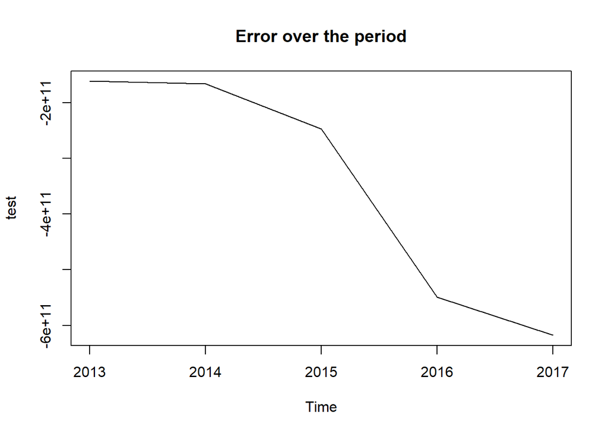

```r
plot(error, main = 'Error over the period')
```

## Question 8:

Calculate the sum of squared errors.

```r
sse_1 = sum(error^2)
sse_1
```

```
## [1] 7.973173e+23
```

## Question 9:

Use the naive() function to forecast for 2013 - 2017 (Test Period.) Did your best model beat the naïve approach?

```r
#Naive Model
forcast_naive = naive(trainBC, h = 5, level = c(80,95))
estimate2 <- InvBoxCox((forcast_naive$mean), lambda = lamda)
error2 = test - estimate2
sse_2 = sum(error2^2)
sse_2
```

```
## [1] 2.233402e+25
```

```r
# For our best model ARIMA(1,2,1)
library(stats)
predicted_best= stats::arima(trainBC, order = c(1, 2, 1))
forecast_bestmodel <- forecast(predicted_best, h = 5)
estimate3 <- InvBoxCox((forecast_bestmodel$mean), lambda = lamda)
error3 = test - estimate3
sse_3 = sum(error3^2)
sse_3
```

```
## [1] 7.369384e+22
```

Since the and the sum of squared errors in the naive model sse_2 = 2.233402e+25, and the sum of squared errors in my best model ARIMA(1,2,1) is sse_3 = 7.369384e+22, sse_2>sse_3. Therefore, my best model beat the naive approach